# Statistical Rethinking Problems: Chapter 6

Simon Thornewill von Essen

2024-03-28

## 6e1

List three mechanisms by which multiple regression can produce false inferences about causal effects.

1. Multicolinearity - When two columns have almost the same information this will cause the inference to become uncertain
2. Post-treatment Bias - When conditioning on a result of the treatment it will make it look as if the treatment is not doing much when it may be
3. Collider Bias - When conditioning on some covariates, they can open unintended information which confound the effect that you’re trying to measure.

## 6e2

For one of the mechanisms in the previous problem, provide an example of your choice, perhaps from your own research.

I think there can be an issue with non-compliance where you randomly assign people to T/C but then there’s the issue of whether or not the person actually follows the treatment that they have been given. If you were to perfectly know this somehow you would need to be careful about how you put this information into your model because it can result in post-treatment bias.

## 6e3

List the four elemental confounds. Can you explain the conditional dependencies of each?

1. The pipe: A -> B -> C
- A *||* C | B
2. The fork: A <- B -> C
- A *||* C | B
3. The collider: A -> B <- C
- A *||* C
- A *|/|* C | B
4. The descendant: A -> B -> C, B -> D
- Conditioning on D will explain variation in B and so will weaken the relationship between A and C.

## 6e4

How is a biased sample like conditioning on a collider? Think of the example at the open of the chapter.

I’m a bit confused by this question so I’m going to skip

## 6m1

Modify the DAG on page 186 to include the variable V, an unobserved cause of C and Y: C ← V → Y. Reanalyze the DAG. How many paths connect X to Y? Which must be closed? Which variables should you condition on now?

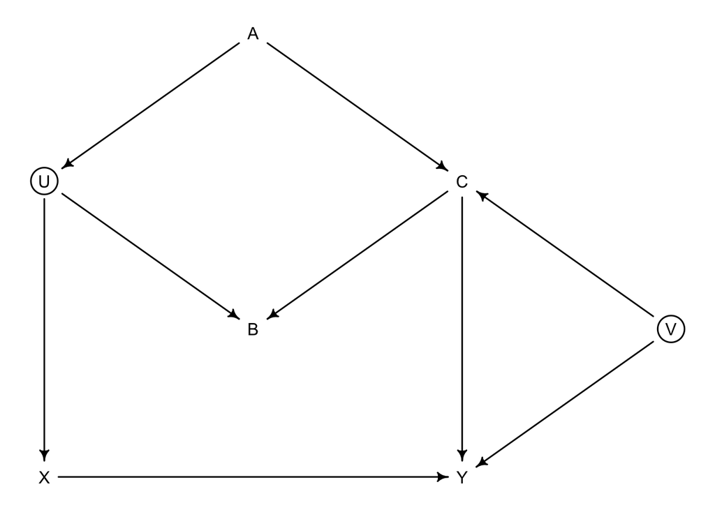

```r
dag.6m1 = dagitty( "dag{
                   U [unobserved]
                   V [unobserved]
                   U <- A -> C
                   U -> B <- C
                   U -> X -> Y
                   C -> Y
                   C <- V -> Y
                   }")
coordinates(dag.6m1) = list( x=c(A=0, B=0, C=0.5, U=-0.5, X=-0.5, Y=0.5, V=1),
                             y=c(A=0, B=1, C=0.5, U=0.5,  X=1.5,  Y=1.5, V=1))

drawdag(dag.6m1)
```

So, how many paths are there connecting X and Y?

Thus, I suppose that we can condition on C, that will block all of the back-door paths from X to Y. Furthermore, conditioning on C will improve precision of our estimate of X on Y.

Ah no, that’s wrong about `A -> C <- V` is a collider, so I shouldn’t do that. Then I’d suppose that we should block on A instead.

Let’s pass this DAG into `dagitty` and see what we get out.

```r
adjustmentSets(dag.6m1, exposure = "X", outcome = "Y")
```

```
## { A }
```

Hey! It correctly realises that we cant condition on `{U}` or `{C, V}` which are alternative adjustment sets and so spits out A.

Can we get daggity to do more analysis?

```r
data.frame(paths(dag.6m1, from = "X", to = "Y"))
```

```
##                        paths  open
## 1                     X -> Y  TRUE
## 2      X <- U -> B <- C -> Y FALSE
## 3 X <- U -> B <- C <- V -> Y FALSE
## 4      X <- U <- A -> C -> Y  TRUE
## 5 X <- U <- A -> C <- V -> Y FALSE
```

Cool! Using this we can see what paths are open and we can see which paths should be closed. Using the adjustment sets above we can find that we can close the `X <- U <- A -> C -> Y` using A.

## 6m2

Sometimes, in order to avoid multicollinearity, people inspect pairwise correlations among predictors before including them in a model. This is a bad procedure, because what matters is the conditional association, not the association before the variables are included in the model. To highlight this, consider the DAG X → Z → Y. Simulate data from this DAG so that the correlation  
between X and Z is very large. Then include both in a model prediction Y. Do you observe any multicollinearity? Why or why not? What is different from the legs example in the chapter?

Ooh, this is a pretty cool example! Right, let’s have a look…

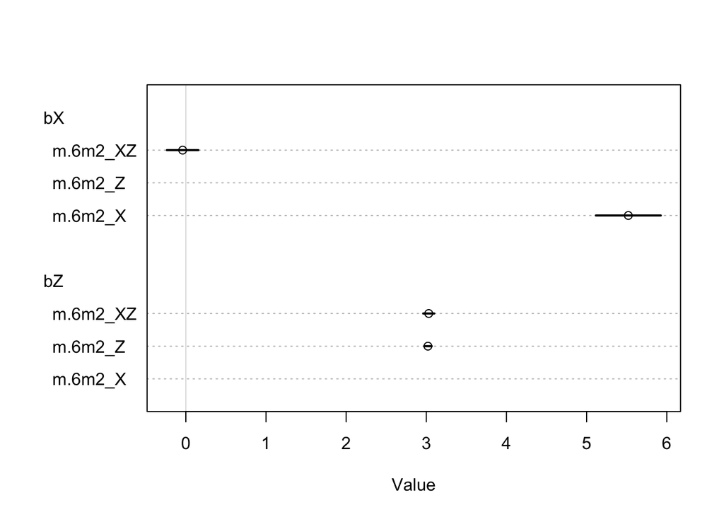

```r
n = 1000
X = rnorm(n)
Z = 2*X + rnorm(n, sd=2)
Y = 3*Z + rnorm(n, sd=2)

d.6m2 = data.frame(X=X, Y=Y, Z=Z)

m.6m2_X = quap(
  alist(
    Y ~ dnorm(mu, sigma),
    mu <- a + bX*X,
    a ~ dnorm(0, 0.2),
    bX ~ dnorm(0, 0.5),
    sigma ~ dunif(0, 100)
  ),
  data=d.6m2
)

m.6m2_Z = quap(
  alist(
    Y ~ dnorm(mu, sigma),
    mu <- a + bZ*Z,
    a ~ dnorm(0, 0.2),
    bZ ~ dnorm(0, 0.5),
    sigma ~ dunif(0, 100)
  ),
  data=d.6m2
)

m.6m2_XZ = quap(
  alist(
    Y ~ dnorm(mu, sigma),
    mu <- a + bX*X + bZ*Z,
    a ~ dnorm(0, 0.2),
    bX ~ dnorm(0, 0.5),
    bZ ~ dnorm(0, 0.5),
    sigma ~ dunif(0, 100)
  ),
  data=d.6m2
)

plot(coeftab(m.6m2_X, m.6m2_Z, m.6m2_XZ), par=c("bX", "bZ"), prob=0.97)
```

I think the coeficients make sense for the uni-variate lm. Where `Y` is definitely `3*Z` and `6*X` but in the regression where both `Z` and `X` terms are present it gets a little confused about the coefficient on `X`.

I suppose it’s because we have information about `X` in `Z`, after accounting for it there should be little information left over that `X` can explain and so its coeff is close to zero.

It’s also interesting beause the multicolinearity problem gets worse the less noise there is between Z and X. Yeah if I make the noise bigger then it gets really precise answers for Z and it does alright for X.

## 6M3

Learning to analyze DAGs requires practice. For each of the four DAGs below, state which variables, if any, you must adjust for (condition on) to estimate the total causal influence of X on Y.

[output not shown]

There seem to be no colliders in this DAG so you can just adjust for Z and that should be enough but you can also adjust for A to improve precision.

```r
dag.6m3.1 = dagitty( "dag{
                   X <- Z -> Y
                   Z <- A -> Y
                   X -> Y
                   }")

adjustmentSets(dag.6m3.1, exposure = 'X', outcome = 'Y')
```

```
## { Z }
```

[output not shown]

Z is a collider now for `X -> Z <- A`

```r
dag.6m3.2 = dagitty( "dag{
                   X -> Z <- Y
                   Z <- A -> Y
                   X -> Y
                   }")

adjustmentSets(dag.6m3.2, exposure = 'X', outcome = 'Y')
```

```
##  {}
```

```
3.
  X -> Z <- Y
  X <- A -> Z
  X -> Y
```

For this one you don’t need to adjust because the back door path is closed and A isn’t important.

```
4.
  X -> Z -> Y
  X <- A -> Z
  X -> Y
```

For this one you need to adjust for Z.

## 6H1

Use the Waffle House data, data(WaffleDivorce), to find the total causal influence of number of Waffle Houses on divorce rate. Justify your model or models with a causal graph.

```r
data(WaffleDivorce)
d.6h1 = WaffleDivorce

d.6h1$D = standardize(d.6h1$Divorce)
d.6h1$M = standardize(d.6h1$Marriage)
d.6h1$A = standardize(d.6h1$MedianAgeMarriage)
d.6h1$W = standardize(d.6h1$WaffleHouses)
d.6h1$S = standardize(d.6h1$South)
```

```r
dag.6h1 = dagitty( "dag{
                   D <- A <- S
                   S -> W -> D
                   A -> M <- S
                   M -> D
                   }")

adjustmentSets(dag.6h1, exposure = 'W', outcome = 'D')
```

```
## { A, M }
## { S }
```

We can see that if we propose the adjustment set as follows then we can calculate the effect of W on D.

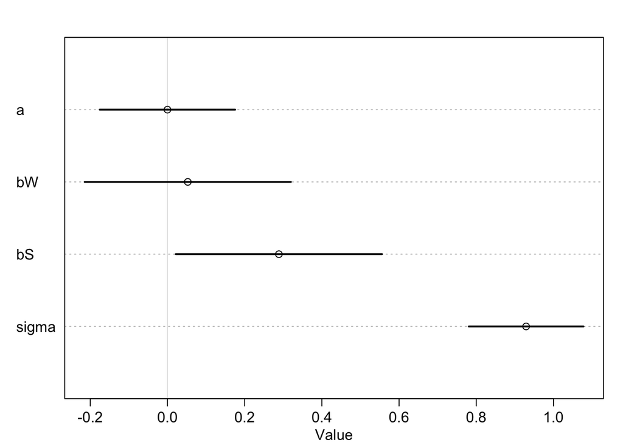

```r
m.6h1 = quap(
  alist(
    D ~ dnorm(mu, sigma),
    mu <- a + bW*W + bS*S,
    a ~ dnorm(0, 0.2),
    bW~ dnorm(0, 0.5),
    bS ~ dnorm(0, 0.5),
    sigma ~ dunif(0, 100)
  ),
  data=d.6h1
)

plot(m.6h1)
```

After conditioning on S we can see that there is no reliable signal between `W` and `D`.

## 6H2

Build a series of models to test the implied conditional independencies of the causal graph you used in the previous problem. If any of the tests fail, how do you think the graph needs to be amended? Does the graph need more or fewer arrows? Feel free to nominate variables that aren’t in the data.

```r
impliedConditionalIndependencies(dag.6h1)
```

```
## A _||_ W | S
## D _||_ S | A, M, W
## M _||_ W | S
```

Okay, so there are a number of conditional independancies that should be possible in this DAG.

1. After knowing that a country is in the South, age of marriage and waffle houses should be conditionally indep.
2. After knowing Age of Marriage, Marriage Status and Wafflehouses, Divorce and being in the South should be conditionally indep.
3. After knowing being in the south, marriage status and Wafflehouses should be conditionally indep.

All of these hypotheses are quite interesting, let’s take a look!

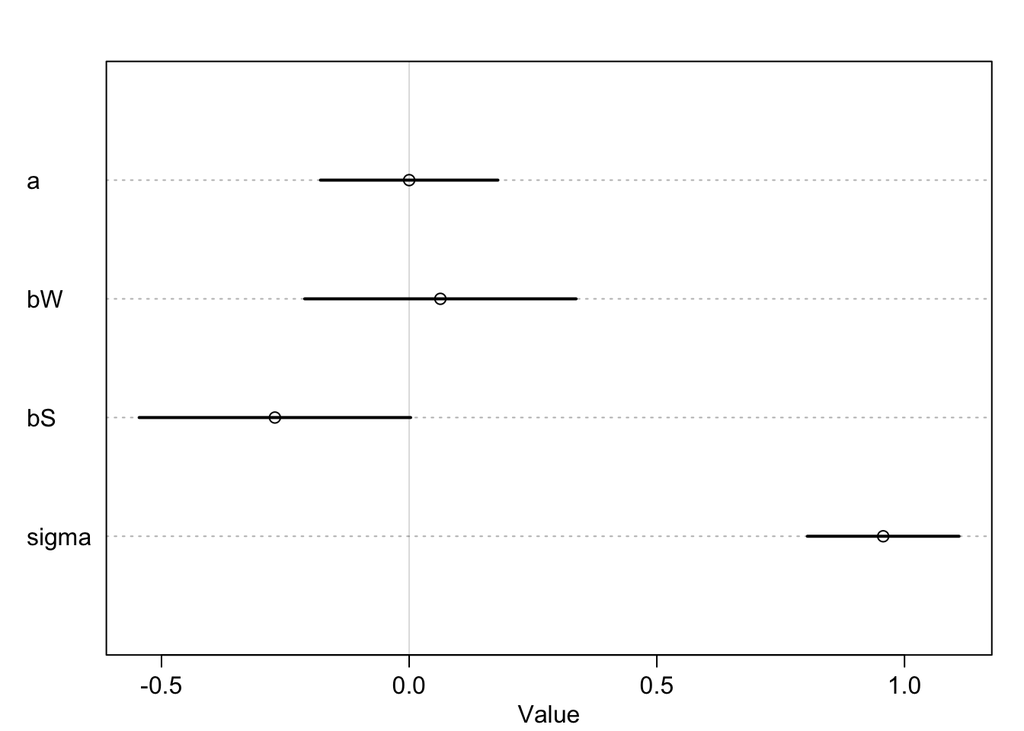

```r
m.6h2.1 = quap(
  alist(
    A ~ dnorm(mu, sigma),
    mu <- a + bW*W + bS*S,
    a ~ dnorm(0, 0.2),
    bW~ dnorm(0, 0.5),
    bS ~ dnorm(0, 0.5),
    sigma ~ dunif(0, 100)
  ),
  data=d.6h1
)

plot(m.6h2.1)
```

Indeed, after we know that we are in the south, waffle houses gives no information on the median age of marraige.

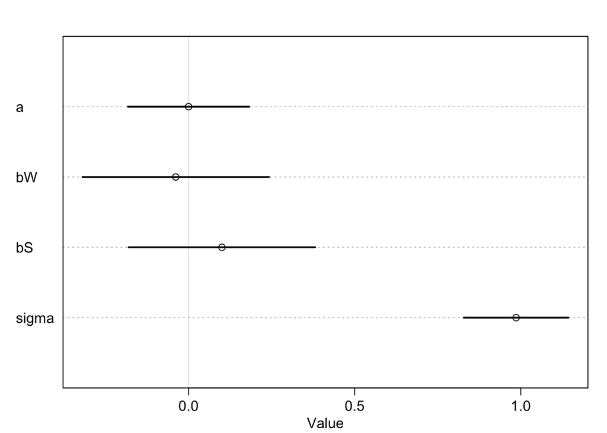

```r
m.6h2.2 = quap(
  alist(
    M ~ dnorm(mu, sigma),
    mu <- a + bW*W + bS*S,
    a ~ dnorm(0, 0.2),
    bW~ dnorm(0, 0.5),
    bS ~ dnorm(0, 0.5),
    sigma ~ dunif(0, 100)
  ),
  data=d.6h1
)

plot(m.6h2.2)
```

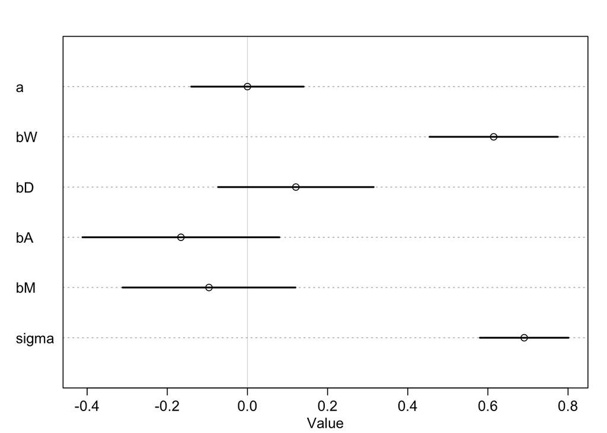

```r
m.6h2.3 = quap(
  alist(
    S ~ dnorm(mu, sigma),
    mu <- a + bW*W + bD*D + bM*M + bA*A,
    a ~ dnorm(0, 0.2),
    bW ~ dnorm(0, 0.5),
    bD ~ dnorm(0, 0.5),
    bA ~ dnorm(0, 0.5),
    bM ~ dnorm(0, 0.5),
    sigma ~ dunif(0, 100)
  ),
  data=d.6h1
)

plot(m.6h2.3)
```

And, furthermore, once we know everything else then S and D aren’t meaningfully linked either.

All of this implies that the DAG is pretty sound.

## 6H3

The data in `data(foxes)` are 116 foxes from 30 different urban groups in England. These foxes are like street gangs. Group size varies from 2 to 8 individuals. Each group maintains its own urban territory. Some territories are larger than others. The area variable encodes this information. Some territories also have more avgfood than others. We want to model the weight of each fox.

Use a model to infer the total causal influence of area on weight. Would increasing the area available to each fox make it heavier (healthier)? You might want to standardize the variables. Regardless, use prior predictive simulation to show that your model’s prior predictions stay within the possible outcome range.

```r
data(foxes)
d.6h3 = foxes

d.6h3$F = standardize(d.6h3$avgfood)
d.6h3$A = d.6h3$area
d.6h3$W = standardize(d.6h3$weight)
d.6h3$G = d.6h3$groupsize
```

Now that we have the data, let’s take a look at the DAG. We can see that `A -> F -> W` and `A -> F -> G -> W` are all open pipes and so if we regress one on the other I think that should give us the total effect…

```r
m.6h3 = quap(
  alist(
    W ~ dnorm(mu, sigma),
    mu <- a + bA*A,
    a ~ dnorm(0, 0.2),
    bA~ dnorm(0, 0.5),
    sigma ~ dunif(0, 100)
  ),
  data=d.6h3
)
```

Now that we have the model, we should do a prior predictive simulation…

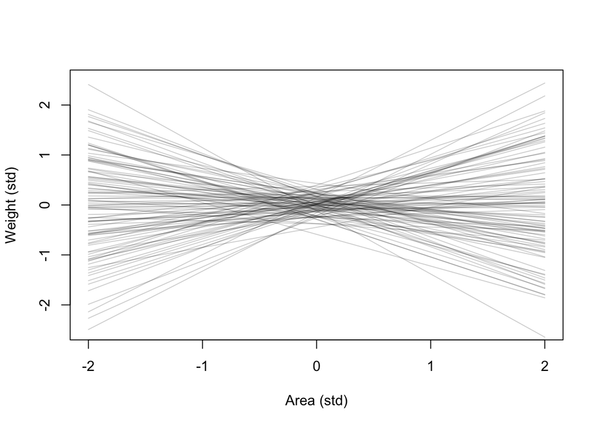

```r
N <- 1000
a_prior <- rnorm(N,0,0.2)
bA_prior <- rnorm(N,0,0.5)
sigma_prior <- rexp(N,1)

seq_A <- seq( from=-2 , to=2 , length.out=30 )
prior <- extract.prior(m.6h3)
mu <- link( m.6h3 , data=list(A=seq_A) , post=prior )
mu_mean <- apply( mu , 2 , mean )

plot( NULL , xlim=c(-2,2) , ylim=c(-2.5,2.5) , xlab="Area (std)" ,
      ylab="Weight (std)")
for ( i in 1:100 )
  lines( seq_A , mu[i,], col=col.alpha("black", 0.2))
```

Yeah, the prior predicions look reasonable…

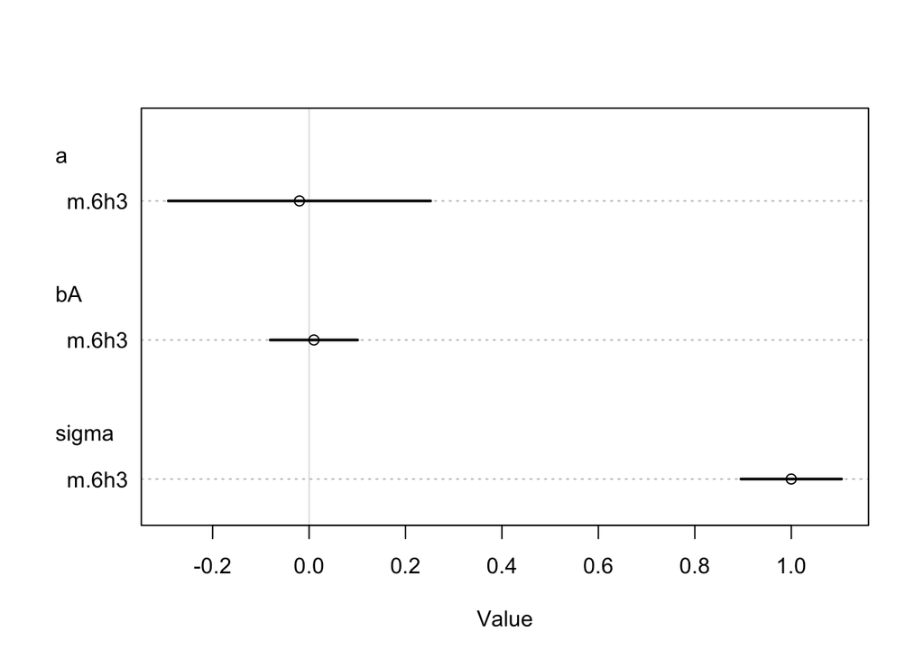

```r
plot(coeftab(m.6h3), prob=0.89)
```

Anyway, it seems that the total effect of area on weight is very close to 0. Which wasn’t what I was expecting.

## 6H4

Now infer the causal impact of adding food to a territory. Would this make foxes heavier? Which covariates do you need to adjust for to estimate the total causal influence of food?

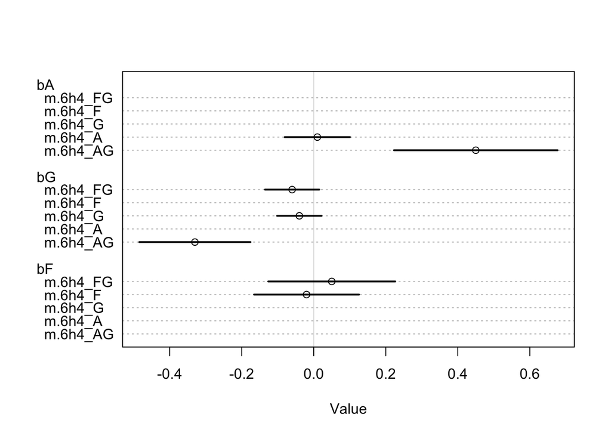

```r
m.6h4_A = quap(
  alist(
    W ~ dnorm(mu, sigma),
    mu <- a + bA*A,
    a ~ dnorm(0, 0.2),
    bA ~ dnorm(0, 0.5),
    sigma ~ dunif(0, 100)
  ),
  data=d.6h3
)

m.6h4_G = quap(
  alist(
    W ~ dnorm(mu, sigma),
    mu <- a + bG*G,
    a ~ dnorm(0, 0.2),
    bG ~ dnorm(0, 0.5),
    sigma ~ dunif(0, 100)
  ),
  data=d.6h3
)

m.6h4_AG = quap(
  alist(
    W ~ dnorm(mu, sigma),
    mu <- a + bA*A + bG*G,
    a ~ dnorm(0, 0.2),
    bA ~ dnorm(0, 0.5),
    bG ~ dnorm(0, 0.5),
    sigma ~ dunif(0, 100)
  ),
  data=d.6h3
)

m.6h4_F = quap(
  alist(
    W ~ dnorm(mu, sigma),
    mu <- a + bF*F,
    a ~ dnorm(0, 0.2),
    bF ~ dnorm(0, 0.5),
    sigma ~ dunif(0, 100)
  ),
  data=d.6h3
)

m.6h4_FG = quap(
  alist(
    W ~ dnorm(mu, sigma),
    mu <- a + bF*F + bG*G,
    a ~ dnorm(0, 0.2),
    bF ~ dnorm(0, 0.5),
    bG ~ dnorm(0, 0.5),
    sigma ~ dunif(0, 100)
  ),
  data=d.6h3
)

plot(coeftab(m.6h4_AG, m.6h4_A, m.6h4_G, m.6h4_F, m.6h4_FG),
     par=c("bA", "bG", "bF"), prob=0.89)
```

It was a bit tricky to analyse this dataset because there was a masking effect from group size and area

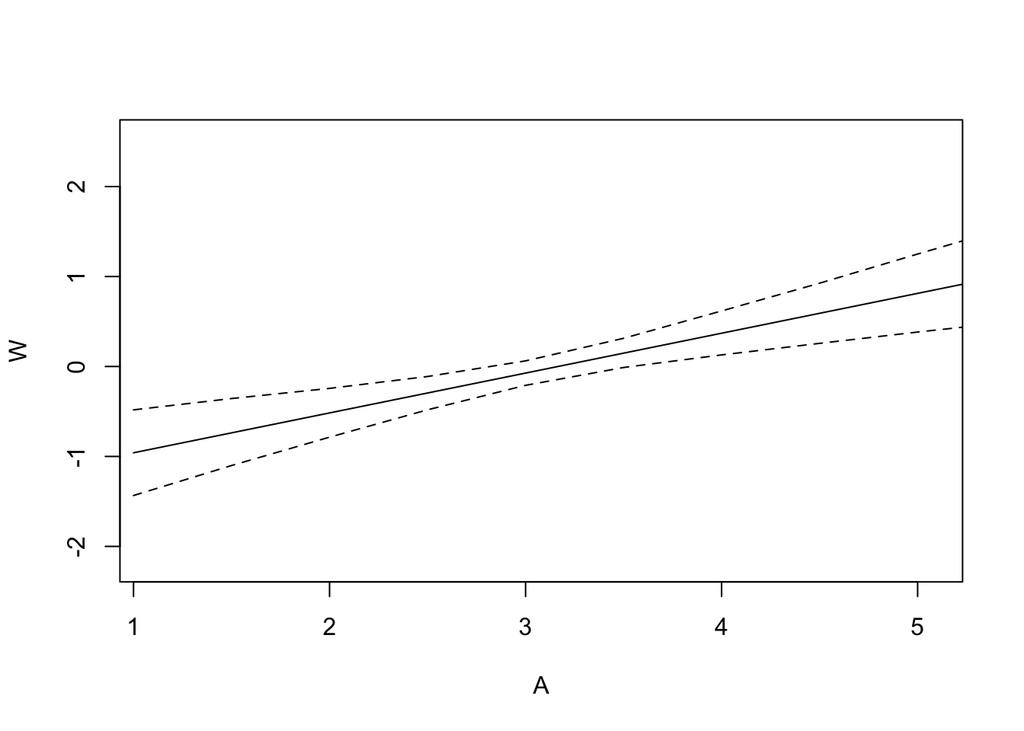

```r
area.seq <- seq(from=1,to=6,by=0.5)
pred.dat <- data.frame( A=area.seq , G=mean(d.6h3$G) )
mu <- link( m.6h4_AG , data=pred.dat )
mu.mean <- apply( mu , 2 , mean )
mu.ci <- apply( mu , 2 , PI )
plot( W ~ A , data=d.6h3 , type="n" )
lines( area.seq , mu.mean )
lines( area.seq , mu.ci[1,] , lty=2 )
lines( area.seq , mu.ci[2,] , lty=2 )
```

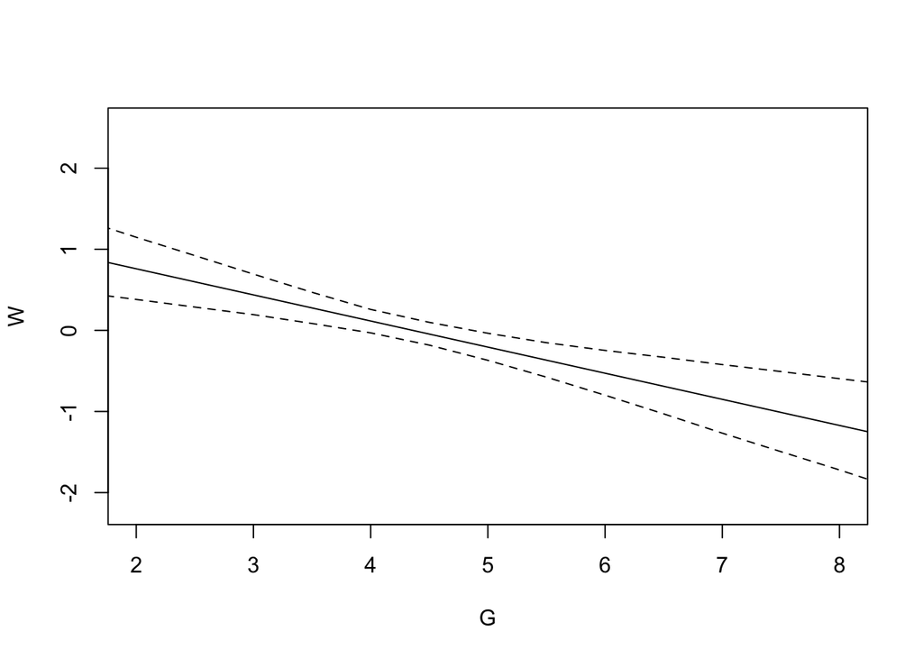

```r
gs.seq <- seq(from=1,to=9,by=0.5)
pred.dat <- data.frame( A=mean(d.6h3$area) , G=gs.seq )
mu <- link( m.6h4_AG , data=pred.dat )
mu.mean <- apply( mu , 2 , mean )
mu.ci <- apply( mu , 2 , PI )
plot( W ~ G , data=d.6h3 , type="n" )
lines( gs.seq , mu.mean )
lines( gs.seq , mu.ci[1,] , lty=2 )
lines( gs.seq , mu.ci[2,] , lty=2 )
```